# Risk Factor Analysis

## Outcome Variable

**Outcome Variable:** ever_stunted

## Predictor Variables

**Intervention Variable:** impsan

**Adjustment Set:**

- arm
- W_mage
- meducyrs
- feducyrs
- hhwealth_quart
- hfoodsec
- W_mhtcm
- W_nrooms
- W_nchldlt5
- W_parity
- impfloor
- safeh20
- delta_W_mage
- delta_meducyrs
- delta_feducyrs
- delta_hhwealth_quart
- delta_hfoodsec
- delta_W_mhtcm
- delta_W_nrooms
- delta_W_nchldlt5
- delta_W_parity
- delta_impfloor
- delta_safeh20

## Stratifying Variables

The analysis was stratified on these variable(s):

- agecat
- studyid
- country

## Data Summary

| agecat | studyid | country | impsan | ever_stunted | n_cell | n |
| --- | --- | --- | --- | --- | --- | --- |
| 0-24 months (no birth st.) | ki0047075b-MAL-ED | BANGLADESH | 1 | 0 | 83 | 203 |
| 0-24 months (no birth st.) | ki0047075b-MAL-ED | BANGLADESH | 1 | 1 | 87 | 203 |
| 0-24 months (no birth st.) | ki0047075b-MAL-ED | BANGLADESH | 0 | 0 | 11 | 203 |
| 0-24 months (no birth st.) | ki0047075b-MAL-ED | BANGLADESH | 0 | 1 | 22 | 203 |
| 0-24 months (no birth st.) | ki0047075b-MAL-ED | BRAZIL | 1 | 0 | 157 | 189 |
| 0-24 months (no birth st.) | ki0047075b-MAL-ED | BRAZIL | 1 | 1 | 28 | 189 |
| 0-24 months (no birth st.) | ki0047075b-MAL-ED | BRAZIL | 0 | 0 | 4 | 189 |
| 0-24 months (no birth st.) | ki0047075b-MAL-ED | BRAZIL | 0 | 1 | 0 | 189 |
| 0-24 months (no birth st.) | ki0047075b-MAL-ED | INDIA | 1 | 0 | 45 | 195 |
| 0-24 months (no birth st.) | ki0047075b-MAL-ED | INDIA | 1 | 1 | 43 | 195 |
| 0-24 months (no birth st.) | ki0047075b-MAL-ED | INDIA | 0 | 0 | 46 | 195 |
| 0-24 months (no birth st.) | ki0047075b-MAL-ED | INDIA | 0 | 1 | 61 | 195 |
| 0-24 months (no birth st.) | ki0047075b-MAL-ED | NEPAL | 1 | 0 | 154 | 209 |
| 0-24 months (no birth st.) | ki0047075b-MAL-ED | NEPAL | 1 | 1 | 54 | 209 |
| 0-24 months (no birth st.) | ki0047075b-MAL-ED | NEPAL | 0 | 0 | 1 | 209 |
| 0-24 months (no birth st.) | ki0047075b-MAL-ED | NEPAL | 0 | 1 | 0 | 209 |
| 0-24 months (no birth st.) | ki0047075b-MAL-ED | PERU | 1 | 0 | 26 | 231 |
| 0-24 months (no birth st.) | ki0047075b-MAL-ED | PERU | 1 | 1 | 31 | 231 |
| 0-24 months (no birth st.) | ki0047075b-MAL-ED | PERU | 0 | 0 | 63 | 231 |
| 0-24 months (no birth st.) | ki0047075b-MAL-ED | PERU | 0 | 1 | 111 | 231 |
| 0-24 months (no birth st.) | ki0047075b-MAL-ED | SOUTH AFRICA | 1 | 0 | 3 | 227 |
| 0-24 months (no birth st.) | ki0047075b-MAL-ED | SOUTH AFRICA | 1 | 1 | 1 | 227 |
| 0-24 months (no birth st.) | ki0047075b-MAL-ED | SOUTH AFRICA | 0 | 0 | 96 | 227 |
| 0-24 months (no birth st.) | ki0047075b-MAL-ED | SOUTH AFRICA | 0 | 1 | 127 | 227 |
| 0-24 months (no birth st.) | ki0047075b-MAL-ED | TANZANIA, UNITED REPUBLIC OF | 1 | 0 | 0 | 202 |
| 0-24 months (no birth st.) | ki0047075b-MAL-ED | TANZANIA, UNITED REPUBLIC OF | 1 | 1 | 0 | 202 |
| 0-24 months (no birth st.) | ki0047075b-MAL-ED | TANZANIA, UNITED REPUBLIC OF | 0 | 0 | 31 | 202 |
| 0-24 months (no birth st.) | ki0047075b-MAL-ED | TANZANIA, UNITED REPUBLIC OF | 0 | 1 | 171 | 202 |
| 0-24 months (no birth st.) | ki1017093-NIH-Birth | BANGLADESH | 1 | 0 | 92 | 530 |
| 0-24 months (no birth st.) | ki1017093-NIH-Birth | BANGLADESH | 1 | 1 | 111 | 530 |

[output cut: 174 more lines]

The following strata were considered:

- agecat: 0-24 months (no birth st.), studyid: ki0047075b-MAL-ED, country: BANGLADESH
- agecat: 0-24 months (no birth st.), studyid: ki0047075b-MAL-ED, country: BRAZIL
- agecat: 0-24 months (no birth st.), studyid: ki0047075b-MAL-ED, country: INDIA
- agecat: 0-24 months (no birth st.), studyid: ki0047075b-MAL-ED, country: NEPAL
- agecat: 0-24 months (no birth st.), studyid: ki0047075b-MAL-ED, country: PERU
- agecat: 0-24 months (no birth st.), studyid: ki0047075b-MAL-ED, country: SOUTH AFRICA
- agecat: 0-24 months (no birth st.), studyid: ki0047075b-MAL-ED, country: TANZANIA, UNITED REPUBLIC OF
- agecat: 0-24 months (no birth st.), studyid: ki1017093-NIH-Birth, country: BANGLADESH
- agecat: 0-24 months (no birth st.), studyid: ki1017093b-PROVIDE, country: BANGLADESH
- agecat: 0-24 months (no birth st.), studyid: ki1017093c-NIH-Crypto, country: BANGLADESH
- agecat: 0-24 months (no birth st.), studyid: ki1114097-CONTENT, country: PERU
- agecat: 0-24 months (no birth st.), studyid: ki1135781-COHORTS, country: GUATEMALA
- agecat: 0-24 months (no birth st.), studyid: ki1135781-COHORTS, country: INDIA
- agecat: 0-24 months (no birth st.), studyid: ki1135781-COHORTS, country: PHILIPPINES
- agecat: 0-24 months (no birth st.), studyid: ki1148112-LCNI-5, country: MALAWI
- agecat: 0-24 months (no birth st.), studyid: kiGH5241-JiVitA-3, country: BANGLADESH
- agecat: 0-24 months (no birth st.), studyid: kiGH5241-JiVitA-4, country: BANGLADESH
- agecat: 0-6 months (no birth st.), studyid: ki0047075b-MAL-ED, country: BANGLADESH
- agecat: 0-6 months (no birth st.), studyid: ki0047075b-MAL-ED, country: BRAZIL
- agecat: 0-6 months (no birth st.), studyid: ki0047075b-MAL-ED, country: INDIA
- agecat: 0-6 months (no birth st.), studyid: ki0047075b-MAL-ED, country: NEPAL
- agecat: 0-6 months (no birth st.), studyid: ki0047075b-MAL-ED, country: PERU
- agecat: 0-6 months (no birth st.), studyid: ki0047075b-MAL-ED, country: SOUTH AFRICA
- agecat: 0-6 months (no birth st.), studyid: ki0047075b-MAL-ED, country: TANZANIA, UNITED REPUBLIC OF
- agecat: 0-6 months (no birth st.), studyid: ki1017093-NIH-Birth, country: BANGLADESH
- agecat: 0-6 months (no birth st.), studyid: ki1017093b-PROVIDE, country: BANGLADESH
- agecat: 0-6 months (no birth st.), studyid: ki1017093c-NIH-Crypto, country: BANGLADESH
- agecat: 0-6 months (no birth st.), studyid: ki1114097-CONTENT, country: PERU
- agecat: 0-6 months (no birth st.), studyid: ki1135781-COHORTS, country: GUATEMALA
- agecat: 0-6 months (no birth st.), studyid: ki1135781-COHORTS, country: INDIA
- agecat: 0-6 months (no birth st.), studyid: ki1135781-COHORTS, country: PHILIPPINES
- agecat: 0-6 months (no birth st.), studyid: ki1148112-LCNI-5, country: MALAWI
- agecat: 0-6 months (no birth st.), studyid: kiGH5241-JiVitA-3, country: BANGLADESH
- agecat: 0-6 months (no birth st.), studyid: kiGH5241-JiVitA-4, country: BANGLADESH
- agecat: 6-24 months, studyid: ki0047075b-MAL-ED, country: BANGLADESH
- agecat: 6-24 months, studyid: ki0047075b-MAL-ED, country: BRAZIL
- agecat: 6-24 months, studyid: ki0047075b-MAL-ED, country: INDIA
- agecat: 6-24 months, studyid: ki0047075b-MAL-ED, country: NEPAL
- agecat: 6-24 months, studyid: ki0047075b-MAL-ED, country: PERU
- agecat: 6-24 months, studyid: ki0047075b-MAL-ED, country: SOUTH AFRICA
- agecat: 6-24 months, studyid: ki0047075b-MAL-ED, country: TANZANIA, UNITED REPUBLIC OF
- agecat: 6-24 months, studyid: ki1017093-NIH-Birth, country: BANGLADESH
- agecat: 6-24 months, studyid: ki1017093b-PROVIDE, country: BANGLADESH
- agecat: 6-24 months, studyid: ki1017093c-NIH-Crypto, country: BANGLADESH
- agecat: 6-24 months, studyid: ki1114097-CONTENT, country: PERU
- agecat: 6-24 months, studyid: ki1135781-COHORTS, country: GUATEMALA
- agecat: 6-24 months, studyid: ki1135781-COHORTS, country: INDIA
- agecat: 6-24 months, studyid: ki1135781-COHORTS, country: PHILIPPINES
- agecat: 6-24 months, studyid: ki1148112-LCNI-5, country: MALAWI
- agecat: 6-24 months, studyid: kiGH5241-JiVitA-3, country: BANGLADESH
- agecat: 6-24 months, studyid: kiGH5241-JiVitA-4, country: BANGLADESH

### Dropped Strata

Some strata were dropped due to rare outcomes:

- agecat: 0-24 months (no birth st.), studyid: ki0047075b-MAL-ED, country: BRAZIL
- agecat: 0-24 months (no birth st.), studyid: ki0047075b-MAL-ED, country: NEPAL
- agecat: 0-24 months (no birth st.), studyid: ki0047075b-MAL-ED, country: SOUTH AFRICA
- agecat: 0-24 months (no birth st.), studyid: ki0047075b-MAL-ED, country: TANZANIA, UNITED REPUBLIC OF
- agecat: 0-24 months (no birth st.), studyid: ki1148112-LCNI-5, country: MALAWI
- agecat: 0-6 months (no birth st.), studyid: ki0047075b-MAL-ED, country: BRAZIL
- agecat: 0-6 months (no birth st.), studyid: ki0047075b-MAL-ED, country: NEPAL
- agecat: 0-6 months (no birth st.), studyid: ki0047075b-MAL-ED, country: SOUTH AFRICA
- agecat: 0-6 months (no birth st.), studyid: ki0047075b-MAL-ED, country: TANZANIA, UNITED REPUBLIC OF
- agecat: 0-6 months (no birth st.), studyid: ki1148112-LCNI-5, country: MALAWI
- agecat: 6-24 months, studyid: ki0047075b-MAL-ED, country: BRAZIL
- agecat: 6-24 months, studyid: ki0047075b-MAL-ED, country: NEPAL
- agecat: 6-24 months, studyid: ki0047075b-MAL-ED, country: SOUTH AFRICA
- agecat: 6-24 months, studyid: ki0047075b-MAL-ED, country: TANZANIA, UNITED REPUBLIC OF
- agecat: 6-24 months, studyid: ki1114097-CONTENT, country: PERU
- agecat: 6-24 months, studyid: ki1148112-LCNI-5, country: MALAWI

## Methods Detail

We’re interested in the causal parameters $E[Y_a]$ for all values of $a \in \mathcal{A}$. These parameters represent the mean outcome if, possibly contrary to fact, we intervened to set all units to have $A=a$. Under the randomization and positivity assumptions, these are identified by the statistical parameters $\psi_a=E_W[E_{Y|A,W}(Y|A=a,W)]$. In addition, we’re interested in the mean of $Y$, $E[Y]$ under no intervention (the observed mean). We will estimate these parameters by using SuperLearner to fit the relevant likelihood factors – $E_{Y|A,W}(Y|A=a,W)$ and $p(A=a|W)$, and then updating our likelihood fit using a joint TMLE.

For unadjusted analyses ($W=\{\}$), initial likelihoods were estimated using Lrnr_glm to estimate the simple $E(Y|A)$ and Lrnr_mean to estimate $p(A)$. For adjusted analyses, a small library containing Lrnr_glmnet, Lrnr_xgboost, and Lrnr_mean was used.

Having estimated these parameters, we will then use the delta method to estimate relative risks and attributable risks relative to a prespecified baseline level of $A$.

# Results Detail

## Results Plots

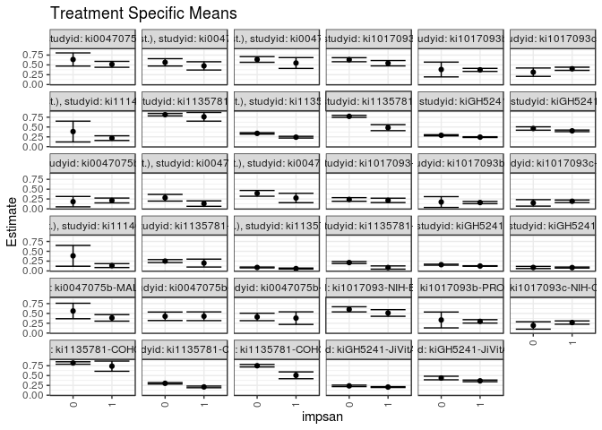

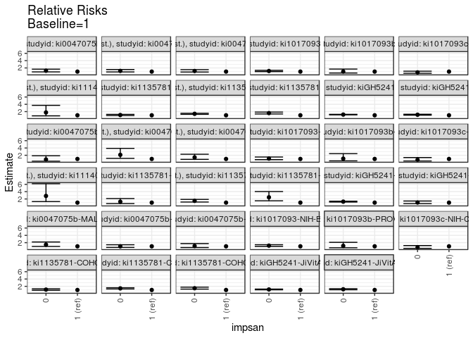

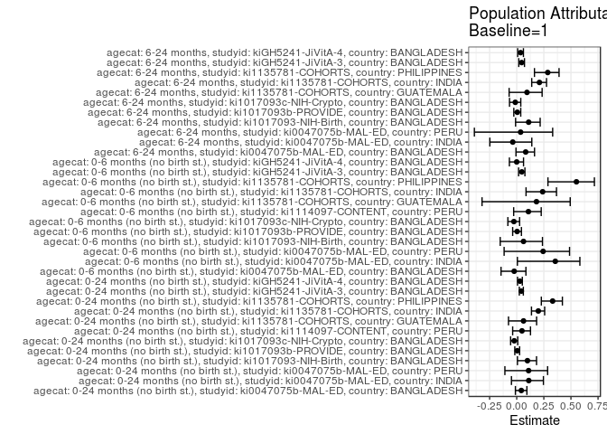

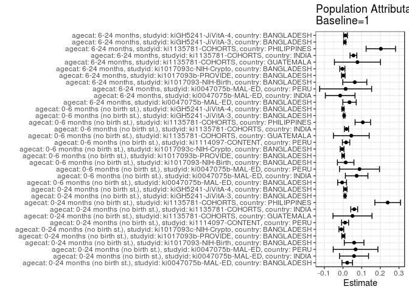

## Results Table

### Parameter: TSM

| agecat | studyid | country | intervention_level | baseline_level | estimate | ci_lower | ci_upper |
| --- | --- | --- | --- | --- | --- | --- | --- |
| 0-24 months (no birth st.) | ki0047075b-MAL-ED | BANGLADESH | 1 | NA | 0.5142745 | 0.4394149 | 0.5891342 |
| 0-24 months (no birth st.) | ki0047075b-MAL-ED | BANGLADESH | 0 | NA | 0.6373923 | 0.4695040 | 0.8052806 |
| 0-24 months (no birth st.) | ki0047075b-MAL-ED | INDIA | 1 | NA | 0.4741912 | 0.3686585 | 0.5797239 |
| 0-24 months (no birth st.) | ki0047075b-MAL-ED | INDIA | 0 | NA | 0.5647245 | 0.4713524 | 0.6580967 |
| 0-24 months (no birth st.) | ki0047075b-MAL-ED | PERU | 1 | NA | 0.5475012 | 0.4102679 | 0.6847345 |
| 0-24 months (no birth st.) | ki0047075b-MAL-ED | PERU | 0 | NA | 0.6376256 | 0.5658561 | 0.7093951 |
| 0-24 months (no birth st.) | ki1017093-NIH-Birth | BANGLADESH | 1 | NA | 0.5423749 | 0.4742587 | 0.6104910 |
| 0-24 months (no birth st.) | ki1017093-NIH-Birth | BANGLADESH | 0 | NA | 0.6314849 | 0.5798705 | 0.6830993 |
| 0-24 months (no birth st.) | ki1017093b-PROVIDE | BANGLADESH | 1 | NA | 0.3732423 | 0.3346453 | 0.4118394 |
| 0-24 months (no birth st.) | ki1017093b-PROVIDE | BANGLADESH | 0 | NA | 0.3821359 | 0.1938653 | 0.5704066 |
| 0-24 months (no birth st.) | ki1017093c-NIH-Crypto | BANGLADESH | 1 | NA | 0.4008978 | 0.3607054 | 0.4410902 |
| 0-24 months (no birth st.) | ki1017093c-NIH-Crypto | BANGLADESH | 0 | NA | 0.3143544 | 0.2080635 | 0.4206452 |
| 0-24 months (no birth st.) | ki1114097-CONTENT | PERU | 1 | NA | 0.2173913 | 0.1576413 | 0.2771413 |
| 0-24 months (no birth st.) | ki1114097-CONTENT | PERU | 0 | NA | 0.3846154 | 0.1194797 | 0.6497510 |
| 0-24 months (no birth st.) | ki1135781-COHORTS | GUATEMALA | 1 | NA | 0.7602343 | 0.6491900 | 0.8712786 |
| 0-24 months (no birth st.) | ki1135781-COHORTS | GUATEMALA | 0 | NA | 0.8143284 | 0.7823667 | 0.8462901 |
| 0-24 months (no birth st.) | ki1135781-COHORTS | INDIA | 1 | NA | 0.2413533 | 0.2198149 | 0.2628917 |
| 0-24 months (no birth st.) | ki1135781-COHORTS | INDIA | 0 | NA | 0.3379620 | 0.3205469 | 0.3553772 |
| 0-24 months (no birth st.) | ki1135781-COHORTS | PHILIPPINES | 1 | NA | 0.4835384 | 0.4080002 | 0.5590766 |
| 0-24 months (no birth st.) | ki1135781-COHORTS | PHILIPPINES | 0 | NA | 0.7718267 | 0.7450102 | 0.7986432 |
| 0-24 months (no birth st.) | kiGH5241-JiVitA-3 | BANGLADESH | 1 | NA | 0.2428220 | 0.2338558 | 0.2517883 |
| 0-24 months (no birth st.) | kiGH5241-JiVitA-3 | BANGLADESH | 0 | NA | 0.2887377 | 0.2738225 | 0.3036529 |
| 0-24 months (no birth st.) | kiGH5241-JiVitA-4 | BANGLADESH | 1 | NA | 0.4021718 | 0.3819456 | 0.4223980 |
| 0-24 months (no birth st.) | kiGH5241-JiVitA-4 | BANGLADESH | 0 | NA | 0.4621114 | 0.4188631 | 0.5053597 |
| 0-6 months (no birth st.) | ki0047075b-MAL-ED | BANGLADESH | 1 | NA | 0.2117647 | 0.1501973 | 0.2733321 |
| 0-6 months (no birth st.) | ki0047075b-MAL-ED | BANGLADESH | 0 | NA | 0.1818182 | 0.0498993 | 0.3137371 |
| 0-6 months (no birth st.) | ki0047075b-MAL-ED | INDIA | 1 | NA | 0.1321535 | 0.0635080 | 0.2007990 |
| 0-6 months (no birth st.) | ki0047075b-MAL-ED | INDIA | 0 | NA | 0.2814079 | 0.1964656 | 0.3663501 |
| 0-6 months (no birth st.) | ki0047075b-MAL-ED | PERU | 1 | NA | 0.2751312 | 0.1554238 | 0.3948385 |
| 0-6 months (no birth st.) | ki0047075b-MAL-ED | PERU | 0 | NA | 0.3929306 | 0.3196582 | 0.4662030 |
| 0-6 months (no birth st.) | ki1017093-NIH-Birth | BANGLADESH | 1 | NA | 0.2140030 | 0.1583827 | 0.2696233 |
| 0-6 months (no birth st.) | ki1017093-NIH-Birth | BANGLADESH | 0 | NA | 0.2380126 | 0.1919466 | 0.2840785 |
| 0-6 months (no birth st.) | ki1017093b-PROVIDE | BANGLADESH | 1 | NA | 0.1592040 | 0.1299789 | 0.1884291 |
| 0-6 months (no birth st.) | ki1017093b-PROVIDE | BANGLADESH | 0 | NA | 0.1724138 | 0.0348242 | 0.3100034 |
| 0-6 months (no birth st.) | ki1017093c-NIH-Crypto | BANGLADESH | 1 | NA | 0.1915156 | 0.1591905 | 0.2238407 |
| 0-6 months (no birth st.) | ki1017093c-NIH-Crypto | BANGLADESH | 0 | NA | 0.1499340 | 0.0677771 | 0.2320909 |
| 0-6 months (no birth st.) | ki1114097-CONTENT | PERU | 1 | NA | 0.1358696 | 0.0862338 | 0.1855054 |
| 0-6 months (no birth st.) | ki1114097-CONTENT | PERU | 0 | NA | 0.3846154 | 0.1194797 | 0.6497510 |
| 0-6 months (no birth st.) | ki1135781-COHORTS | GUATEMALA | 1 | NA | 0.1997644 | 0.0994005 | 0.3001283 |
| 0-6 months (no birth st.) | ki1135781-COHORTS | GUATEMALA | 0 | NA | 0.2506711 | 0.2128759 | 0.2884662 |
| 0-6 months (no birth st.) | ki1135781-COHORTS | INDIA | 1 | NA | 0.0596219 | 0.0471340 | 0.0721099 |
| 0-6 months (no birth st.) | ki1135781-COHORTS | INDIA | 0 | NA | 0.0884579 | 0.0780332 | 0.0988826 |
| 0-6 months (no birth st.) | ki1135781-COHORTS | PHILIPPINES | 1 | NA | 0.0866565 | 0.0451716 | 0.1281414 |
| 0-6 months (no birth st.) | ki1135781-COHORTS | PHILIPPINES | 0 | NA | 0.2129975 | 0.1868004 | 0.2391946 |
| 0-6 months (no birth st.) | kiGH5241-JiVitA-3 | BANGLADESH | 1 | NA | 0.1250464 | 0.1184594 | 0.1316333 |
| 0-6 months (no birth st.) | kiGH5241-JiVitA-3 | BANGLADESH | 0 | NA | 0.1590792 | 0.1460465 | 0.1721120 |
| 0-6 months (no birth st.) | kiGH5241-JiVitA-4 | BANGLADESH | 1 | NA | 0.0854807 | 0.0727021 | 0.0982594 |
| 0-6 months (no birth st.) | kiGH5241-JiVitA-4 | BANGLADESH | 0 | NA | 0.0879816 | 0.0603110 | 0.1156522 |
| 6-24 months | ki0047075b-MAL-ED | BANGLADESH | 1 | NA | 0.3865848 | 0.3037953 | 0.4693743 |
| 6-24 months | ki0047075b-MAL-ED | BANGLADESH | 0 | NA | 0.5618250 | 0.3648656 | 0.7587845 |
| 6-24 months | ki0047075b-MAL-ED | INDIA | 1 | NA | 0.4279904 | 0.3170356 | 0.5389453 |
| 6-24 months | ki0047075b-MAL-ED | INDIA | 0 | NA | 0.4270231 | 0.3192679 | 0.5347783 |
| 6-24 months | ki0047075b-MAL-ED | PERU | 1 | NA | 0.3804284 | 0.2204820 | 0.5403749 |
| 6-24 months | ki0047075b-MAL-ED | PERU | 0 | NA | 0.4099523 | 0.3149713 | 0.5049333 |
| 6-24 months | ki1017093-NIH-Birth | BANGLADESH | 1 | NA | 0.5108021 | 0.4268664 | 0.5947378 |
| 6-24 months | ki1017093-NIH-Birth | BANGLADESH | 0 | NA | 0.6038696 | 0.5388058 | 0.6689334 |
| 6-24 months | ki1017093b-PROVIDE | BANGLADESH | 1 | NA | 0.2972350 | 0.2541887 | 0.3402813 |
| 6-24 months | ki1017093b-PROVIDE | BANGLADESH | 0 | NA | 0.3333333 | 0.1314921 | 0.5351746 |
| 6-24 months | ki1017093c-NIH-Crypto | BANGLADESH | 1 | NA | 0.2674947 | 0.2261371 | 0.3088523 |
| 6-24 months | ki1017093c-NIH-Crypto | BANGLADESH | 0 | NA | 0.1935498 | 0.0997331 | 0.2873666 |
| 6-24 months | ki1135781-COHORTS | GUATEMALA | 1 | NA | 0.7389941 | 0.6089877 | 0.8690006 |
| 6-24 months | ki1135781-COHORTS | GUATEMALA | 0 | NA | 0.8198822 | 0.7881812 | 0.8515833 |
| 6-24 months | ki1135781-COHORTS | INDIA | 1 | NA | 0.2108308 | 0.1893603 | 0.2323013 |
| 6-24 months | ki1135781-COHORTS | INDIA | 0 | NA | 0.3028391 | 0.2845464 | 0.3211318 |
| 6-24 months | ki1135781-COHORTS | PHILIPPINES | 1 | NA | 0.5060397 | 0.4189620 | 0.5931173 |
| 6-24 months | ki1135781-COHORTS | PHILIPPINES | 0 | NA | 0.7502686 | 0.7183554 | 0.7821818 |
| 6-24 months | kiGH5241-JiVitA-3 | BANGLADESH | 1 | NA | 0.2074445 | 0.1965467 | 0.2183424 |
| 6-24 months | kiGH5241-JiVitA-3 | BANGLADESH | 0 | NA | 0.2376083 | 0.2190647 | 0.2561519 |
| 6-24 months | kiGH5241-JiVitA-4 | BANGLADESH | 1 | NA | 0.3649635 | 0.3441317 | 0.3857953 |
| 6-24 months | kiGH5241-JiVitA-4 | BANGLADESH | 0 | NA | 0.4376720 | 0.3923778 | 0.4829663 |

### Parameter: E(Y)

| agecat | studyid | country | intervention_level | baseline_level | estimate | ci_lower | ci_upper |
| --- | --- | --- | --- | --- | --- | --- | --- |
| 0-24 months (no birth st.) | ki0047075b-MAL-ED | BANGLADESH | NA | NA | 0.5369458 | 0.4681830 | 0.6057086 |
| 0-24 months (no birth st.) | ki0047075b-MAL-ED | INDIA | NA | NA | 0.5333333 | 0.4631313 | 0.6035354 |
| 0-24 months (no birth st.) | ki0047075b-MAL-ED | PERU | NA | NA | 0.6147186 | 0.5518243 | 0.6776129 |
| 0-24 months (no birth st.) | ki1017093-NIH-Birth | BANGLADESH | NA | NA | 0.6018868 | 0.5601729 | 0.6436007 |
| 0-24 months (no birth st.) | ki1017093b-PROVIDE | BANGLADESH | NA | NA | 0.3750000 | 0.3372263 | 0.4127737 |
| 0-24 months (no birth st.) | ki1017093c-NIH-Crypto | BANGLADESH | NA | NA | 0.3919129 | 0.3541506 | 0.4296752 |
| 0-24 months (no birth st.) | ki1114097-CONTENT | PERU | NA | NA | 0.2284264 | 0.1696529 | 0.2871999 |
| 0-24 months (no birth st.) | ki1135781-COHORTS | GUATEMALA | NA | NA | 0.8110236 | 0.7805500 | 0.8414972 |
| 0-24 months (no birth st.) | ki1135781-COHORTS | INDIA | NA | NA | 0.3013786 | 0.2882798 | 0.3144773 |
| 0-24 months (no birth st.) | ki1135781-COHORTS | PHILIPPINES | NA | NA | 0.7228700 | 0.6965868 | 0.7491531 |
| 0-24 months (no birth st.) | kiGH5241-JiVitA-3 | BANGLADESH | NA | NA | 0.2536189 | 0.2458286 | 0.2614092 |
| 0-24 months (no birth st.) | kiGH5241-JiVitA-4 | BANGLADESH | NA | NA | 0.4144516 | 0.3962595 | 0.4326437 |
| 0-6 months (no birth st.) | ki0047075b-MAL-ED | BANGLADESH | NA | NA | 0.2068966 | 0.1510349 | 0.2627582 |
| 0-6 months (no birth st.) | ki0047075b-MAL-ED | INDIA | NA | NA | 0.2051282 | 0.1483073 | 0.2619492 |
| 0-6 months (no birth st.) | ki0047075b-MAL-ED | PERU | NA | NA | 0.3636364 | 0.3014678 | 0.4258049 |
| 0-6 months (no birth st.) | ki1017093-NIH-Birth | BANGLADESH | NA | NA | 0.2283019 | 0.1925336 | 0.2640702 |
| 0-6 months (no birth st.) | ki1017093b-PROVIDE | BANGLADESH | NA | NA | 0.1598101 | 0.1312195 | 0.1884008 |
| 0-6 months (no birth st.) | ki1017093c-NIH-Crypto | BANGLADESH | NA | NA | 0.1866252 | 0.1564874 | 0.2167630 |
| 0-6 months (no birth st.) | ki1114097-CONTENT | PERU | NA | NA | 0.1522843 | 0.1019837 | 0.2025848 |
| 0-6 months (no birth st.) | ki1135781-COHORTS | GUATEMALA | NA | NA | 0.2442478 | 0.2087898 | 0.2797057 |
| 0-6 months (no birth st.) | ki1135781-COHORTS | INDIA | NA | NA | 0.0783541 | 0.0705612 | 0.0861470 |
| 0-6 months (no birth st.) | ki1135781-COHORTS | PHILIPPINES | NA | NA | 0.1928251 | 0.1696580 | 0.2159922 |
| 0-6 months (no birth st.) | kiGH5241-JiVitA-3 | BANGLADESH | NA | NA | 0.1311885 | 0.1255590 | 0.1368180 |
| 0-6 months (no birth st.) | kiGH5241-JiVitA-4 | BANGLADESH | NA | NA | 0.0854560 | 0.0740923 | 0.0968198 |
| 6-24 months | ki0047075b-MAL-ED | BANGLADESH | NA | NA | 0.4213836 | 0.3443902 | 0.4983771 |
| 6-24 months | ki0047075b-MAL-ED | INDIA | NA | NA | 0.4129032 | 0.3351414 | 0.4906651 |
| 6-24 months | ki0047075b-MAL-ED | PERU | NA | NA | 0.3945578 | 0.3152779 | 0.4738378 |
| 6-24 months | ki1017093-NIH-Birth | BANGLADESH | NA | NA | 0.5739130 | 0.5216565 | 0.6261696 |
| 6-24 months | ki1017093b-PROVIDE | BANGLADESH | NA | NA | 0.2989011 | 0.2567922 | 0.3410100 |
| 6-24 months | ki1017093c-NIH-Crypto | BANGLADESH | NA | NA | 0.2640000 | 0.2253243 | 0.3026757 |
| 6-24 months | ki1135781-COHORTS | GUATEMALA | NA | NA | 0.8162939 | 0.7859345 | 0.8466533 |
| 6-24 months | ki1135781-COHORTS | INDIA | NA | NA | 0.2666991 | 0.2531888 | 0.2802093 |
| 6-24 months | ki1135781-COHORTS | PHILIPPINES | NA | NA | 0.7086331 | 0.6777759 | 0.7394903 |
| 6-24 months | kiGH5241-JiVitA-3 | BANGLADESH | NA | NA | 0.2173417 | 0.2079638 | 0.2267196 |
| 6-24 months | kiGH5241-JiVitA-4 | BANGLADESH | NA | NA | 0.3784303 | 0.3598372 | 0.3970234 |

### Parameter: RR

| agecat | studyid | country | intervention_level | baseline_level | estimate | ci_lower | ci_upper |
| --- | --- | --- | --- | --- | --- | --- | --- |
| 0-24 months (no birth st.) | ki0047075b-MAL-ED | BANGLADESH | 1 | 1 | 1.0000000 | 1.0000000 | 1.000000 |
| 0-24 months (no birth st.) | ki0047075b-MAL-ED | BANGLADESH | 0 | 1 | 1.2394008 | 0.9223168 | 1.665495 |
| 0-24 months (no birth st.) | ki0047075b-MAL-ED | INDIA | 1 | 1 | 1.0000000 | 1.0000000 | 1.000000 |
| 0-24 months (no birth st.) | ki0047075b-MAL-ED | INDIA | 0 | 1 | 1.1909216 | 0.9044328 | 1.568159 |
| 0-24 months (no birth st.) | ki0047075b-MAL-ED | PERU | 1 | 1 | 1.0000000 | 1.0000000 | 1.000000 |
| 0-24 months (no birth st.) | ki0047075b-MAL-ED | PERU | 0 | 1 | 1.1646104 | 0.8843069 | 1.533763 |
| 0-24 months (no birth st.) | ki1017093-NIH-Birth | BANGLADESH | 1 | 1 | 1.0000000 | 1.0000000 | 1.000000 |
| 0-24 months (no birth st.) | ki1017093-NIH-Birth | BANGLADESH | 0 | 1 | 1.1642961 | 1.0039891 | 1.350199 |
| 0-24 months (no birth st.) | ki1017093b-PROVIDE | BANGLADESH | 1 | 1 | 1.0000000 | 1.0000000 | 1.000000 |
| 0-24 months (no birth st.) | ki1017093b-PROVIDE | BANGLADESH | 0 | 1 | 1.0238279 | 0.6193778 | 1.692382 |
| 0-24 months (no birth st.) | ki1017093c-NIH-Crypto | BANGLADESH | 1 | 1 | 1.0000000 | 1.0000000 | 1.000000 |
| 0-24 months (no birth st.) | ki1017093c-NIH-Crypto | BANGLADESH | 0 | 1 | 0.7841259 | 0.5523943 | 1.113070 |
| 0-24 months (no birth st.) | ki1114097-CONTENT | PERU | 1 | 1 | 1.0000000 | 1.0000000 | 1.000000 |
| 0-24 months (no birth st.) | ki1114097-CONTENT | PERU | 0 | 1 | 1.7692308 | 0.8423327 | 3.716082 |
| 0-24 months (no birth st.) | ki1135781-COHORTS | GUATEMALA | 1 | 1 | 1.0000000 | 1.0000000 | 1.000000 |
| 0-24 months (no birth st.) | ki1135781-COHORTS | GUATEMALA | 0 | 1 | 1.0711545 | 0.9213075 | 1.245374 |
| 0-24 months (no birth st.) | ki1135781-COHORTS | INDIA | 1 | 1 | 1.0000000 | 1.0000000 | 1.000000 |
| 0-24 months (no birth st.) | ki1135781-COHORTS | INDIA | 0 | 1 | 1.4002792 | 1.2641417 | 1.551078 |
| 0-24 months (no birth st.) | ki1135781-COHORTS | PHILIPPINES | 1 | 1 | 1.0000000 | 1.0000000 | 1.000000 |
| 0-24 months (no birth st.) | ki1135781-COHORTS | PHILIPPINES | 0 | 1 | 1.5962055 | 1.3611234 | 1.871889 |
| 0-24 months (no birth st.) | kiGH5241-JiVitA-3 | BANGLADESH | 1 | 1 | 1.0000000 | 1.0000000 | 1.000000 |
| 0-24 months (no birth st.) | kiGH5241-JiVitA-3 | BANGLADESH | 0 | 1 | 1.1890917 | 1.1212384 | 1.261051 |
| 0-24 months (no birth st.) | kiGH5241-JiVitA-4 | BANGLADESH | 1 | 1 | 1.0000000 | 1.0000000 | 1.000000 |
| 0-24 months (no birth st.) | kiGH5241-JiVitA-4 | BANGLADESH | 0 | 1 | 1.1490398 | 1.0343290 | 1.276472 |
| 0-6 months (no birth st.) | ki0047075b-MAL-ED | BANGLADESH | 1 | 1 | 1.0000000 | 1.0000000 | 1.000000 |
| 0-6 months (no birth st.) | ki0047075b-MAL-ED | BANGLADESH | 0 | 1 | 0.8585859 | 0.3929374 | 1.876049 |
| 0-6 months (no birth st.) | ki0047075b-MAL-ED | INDIA | 1 | 1 | 1.0000000 | 1.0000000 | 1.000000 |
| 0-6 months (no birth st.) | ki0047075b-MAL-ED | INDIA | 0 | 1 | 2.1294015 | 1.1629716 | 3.898935 |
| 0-6 months (no birth st.) | ki0047075b-MAL-ED | PERU | 1 | 1 | 1.0000000 | 1.0000000 | 1.000000 |
| 0-6 months (no birth st.) | ki0047075b-MAL-ED | PERU | 0 | 1 | 1.4281574 | 0.8895363 | 2.292918 |
| 0-6 months (no birth st.) | ki1017093-NIH-Birth | BANGLADESH | 1 | 1 | 1.0000000 | 1.0000000 | 1.000000 |
| 0-6 months (no birth st.) | ki1017093-NIH-Birth | BANGLADESH | 0 | 1 | 1.1121926 | 0.8071768 | 1.532468 |
| 0-6 months (no birth st.) | ki1017093b-PROVIDE | BANGLADESH | 1 | 1 | 1.0000000 | 1.0000000 | 1.000000 |
| 0-6 months (no birth st.) | ki1017093b-PROVIDE | BANGLADESH | 0 | 1 | 1.0829741 | 0.4775197 | 2.456093 |
| 0-6 months (no birth st.) | ki1017093c-NIH-Crypto | BANGLADESH | 1 | 1 | 1.0000000 | 1.0000000 | 1.000000 |
| 0-6 months (no birth st.) | ki1017093c-NIH-Crypto | BANGLADESH | 0 | 1 | 0.7828812 | 0.4416279 | 1.387827 |
| 0-6 months (no birth st.) | ki1114097-CONTENT | PERU | 1 | 1 | 1.0000000 | 1.0000000 | 1.000000 |
| 0-6 months (no birth st.) | ki1114097-CONTENT | PERU | 0 | 1 | 2.8307692 | 1.2974209 | 6.176295 |
| 0-6 months (no birth st.) | ki1135781-COHORTS | GUATEMALA | 1 | 1 | 1.0000000 | 1.0000000 | 1.000000 |
| 0-6 months (no birth st.) | ki1135781-COHORTS | GUATEMALA | 0 | 1 | 1.2548336 | 0.7431483 | 2.118833 |
| 0-6 months (no birth st.) | ki1135781-COHORTS | INDIA | 1 | 1 | 1.0000000 | 1.0000000 | 1.000000 |
| 0-6 months (no birth st.) | ki1135781-COHORTS | INDIA | 0 | 1 | 1.4836462 | 1.1670402 | 1.886144 |
| 0-6 months (no birth st.) | ki1135781-COHORTS | PHILIPPINES | 1 | 1 | 1.0000000 | 1.0000000 | 1.000000 |
| 0-6 months (no birth st.) | ki1135781-COHORTS | PHILIPPINES | 0 | 1 | 2.4579524 | 1.4988694 | 4.030725 |
| 0-6 months (no birth st.) | kiGH5241-JiVitA-3 | BANGLADESH | 1 | 1 | 1.0000000 | 1.0000000 | 1.000000 |
| 0-6 months (no birth st.) | kiGH5241-JiVitA-3 | BANGLADESH | 0 | 1 | 1.2721622 | 1.1600695 | 1.395086 |
| 0-6 months (no birth st.) | kiGH5241-JiVitA-4 | BANGLADESH | 1 | 1 | 1.0000000 | 1.0000000 | 1.000000 |
| 0-6 months (no birth st.) | kiGH5241-JiVitA-4 | BANGLADESH | 0 | 1 | 1.0292563 | 0.7335869 | 1.444094 |
| 6-24 months | ki0047075b-MAL-ED | BANGLADESH | 1 | 1 | 1.0000000 | 1.0000000 | 1.000000 |
| 6-24 months | ki0047075b-MAL-ED | BANGLADESH | 0 | 1 | 1.4533036 | 0.9696125 | 2.178284 |
| 6-24 months | ki0047075b-MAL-ED | INDIA | 1 | 1 | 1.0000000 | 1.0000000 | 1.000000 |
| 6-24 months | ki0047075b-MAL-ED | INDIA | 0 | 1 | 0.9977398 | 0.6963901 | 1.429493 |
| 6-24 months | ki0047075b-MAL-ED | PERU | 1 | 1 | 1.0000000 | 1.0000000 | 1.000000 |
| 6-24 months | ki0047075b-MAL-ED | PERU | 0 | 1 | 1.0776068 | 0.6658152 | 1.744082 |
| 6-24 months | ki1017093-NIH-Birth | BANGLADESH | 1 | 1 | 1.0000000 | 1.0000000 | 1.000000 |
| 6-24 months | ki1017093-NIH-Birth | BANGLADESH | 0 | 1 | 1.1821987 | 0.9727431 | 1.436755 |
| 6-24 months | ki1017093b-PROVIDE | BANGLADESH | 1 | 1 | 1.0000000 | 1.0000000 | 1.000000 |
| 6-24 months | ki1017093b-PROVIDE | BANGLADESH | 0 | 1 | 1.1214470 | 0.6017088 | 2.090120 |
| 6-24 months | ki1017093c-NIH-Crypto | BANGLADESH | 1 | 1 | 1.0000000 | 1.0000000 | 1.000000 |
| 6-24 months | ki1017093c-NIH-Crypto | BANGLADESH | 0 | 1 | 0.7235651 | 0.4348697 | 1.203916 |
| 6-24 months | ki1135781-COHORTS | GUATEMALA | 1 | 1 | 1.0000000 | 1.0000000 | 1.000000 |
| 6-24 months | ki1135781-COHORTS | GUATEMALA | 0 | 1 | 1.1094570 | 0.9273013 | 1.327395 |
| 6-24 months | ki1135781-COHORTS | INDIA | 1 | 1 | 1.0000000 | 1.0000000 | 1.000000 |
| 6-24 months | ki1135781-COHORTS | INDIA | 0 | 1 | 1.4364083 | 1.2770247 | 1.615684 |
| 6-24 months | ki1135781-COHORTS | PHILIPPINES | 1 | 1 | 1.0000000 | 1.0000000 | 1.000000 |
| 6-24 months | ki1135781-COHORTS | PHILIPPINES | 0 | 1 | 1.4826280 | 1.2427051 | 1.768872 |
| 6-24 months | kiGH5241-JiVitA-3 | BANGLADESH | 1 | 1 | 1.0000000 | 1.0000000 | 1.000000 |
| 6-24 months | kiGH5241-JiVitA-3 | BANGLADESH | 0 | 1 | 1.1454065 | 1.0457752 | 1.254530 |
| 6-24 months | kiGH5241-JiVitA-4 | BANGLADESH | 1 | 1 | 1.0000000 | 1.0000000 | 1.000000 |
| 6-24 months | kiGH5241-JiVitA-4 | BANGLADESH | 0 | 1 | 1.1992213 | 1.0667648 | 1.348124 |

### Parameter: PAR

| agecat | studyid | country | intervention_level | baseline_level | estimate | ci_lower | ci_upper |
| --- | --- | --- | --- | --- | --- | --- | --- |
| 0-24 months (no birth st.) | ki0047075b-MAL-ED | BANGLADESH | 1 | NA | 0.0226713 | -0.0055655 | 0.0509081 |
| 0-24 months (no birth st.) | ki0047075b-MAL-ED | INDIA | 1 | NA | 0.0591421 | -0.0185837 | 0.1368680 |
| 0-24 months (no birth st.) | ki0047075b-MAL-ED | PERU | 1 | NA | 0.0672174 | -0.0524509 | 0.1868857 |
| 0-24 months (no birth st.) | ki1017093-NIH-Birth | BANGLADESH | 1 | NA | 0.0595119 | 0.0069171 | 0.1121068 |
| 0-24 months (no birth st.) | ki1017093b-PROVIDE | BANGLADESH | 1 | NA | 0.0017577 | -0.0065495 | 0.0100648 |
| 0-24 months (no birth st.) | ki1017093c-NIH-Crypto | BANGLADESH | 1 | NA | -0.0089849 | -0.0218298 | 0.0038600 |
| 0-24 months (no birth st.) | ki1114097-CONTENT | PERU | 1 | NA | 0.0110351 | -0.0078182 | 0.0298884 |
| 0-24 months (no birth st.) | ki1135781-COHORTS | GUATEMALA | 1 | NA | 0.0507893 | -0.0537742 | 0.1553528 |
| 0-24 months (no birth st.) | ki1135781-COHORTS | INDIA | 1 | NA | 0.0600253 | 0.0416653 | 0.0783852 |
| 0-24 months (no birth st.) | ki1135781-COHORTS | PHILIPPINES | 1 | NA | 0.2393316 | 0.1706388 | 0.3080243 |
| 0-24 months (no birth st.) | kiGH5241-JiVitA-3 | BANGLADESH | 1 | NA | 0.0107968 | 0.0061111 | 0.0154825 |
| 0-24 months (no birth st.) | kiGH5241-JiVitA-4 | BANGLADESH | 1 | NA | 0.0122798 | 0.0031459 | 0.0214137 |
| 0-6 months (no birth st.) | ki0047075b-MAL-ED | BANGLADESH | 1 | NA | -0.0048682 | -0.0285826 | 0.0188463 |
| 0-6 months (no birth st.) | ki0047075b-MAL-ED | INDIA | 1 | NA | 0.0729747 | 0.0126150 | 0.1333345 |
| 0-6 months (no birth st.) | ki0047075b-MAL-ED | PERU | 1 | NA | 0.0885052 | -0.0185474 | 0.1955578 |
| 0-6 months (no birth st.) | ki1017093-NIH-Birth | BANGLADESH | 1 | NA | 0.0142989 | -0.0299135 | 0.0585112 |
| 0-6 months (no birth st.) | ki1017093b-PROVIDE | BANGLADESH | 1 | NA | 0.0006061 | -0.0058518 | 0.0070640 |
| 0-6 months (no birth st.) | ki1017093c-NIH-Crypto | BANGLADESH | 1 | NA | -0.0048904 | -0.0150025 | 0.0052217 |
| 0-6 months (no birth st.) | ki1114097-CONTENT | PERU | 1 | NA | 0.0164147 | -0.0033740 | 0.0362034 |
| 0-6 months (no birth st.) | ki1135781-COHORTS | GUATEMALA | 1 | NA | 0.0444834 | -0.0512494 | 0.1402162 |
| 0-6 months (no birth st.) | ki1135781-COHORTS | INDIA | 1 | NA | 0.0187322 | 0.0076522 | 0.0298121 |
| 0-6 months (no birth st.) | ki1135781-COHORTS | PHILIPPINES | 1 | NA | 0.1061686 | 0.0646260 | 0.1477112 |
| 0-6 months (no birth st.) | kiGH5241-JiVitA-3 | BANGLADESH | 1 | NA | 0.0061422 | 0.0023172 | 0.0099672 |
| 0-6 months (no birth st.) | kiGH5241-JiVitA-4 | BANGLADESH | 1 | NA | -0.0000247 | -0.0055924 | 0.0055430 |
| 6-24 months | ki0047075b-MAL-ED | BANGLADESH | 1 | NA | 0.0347989 | -0.0010348 | 0.0706326 |
| 6-24 months | ki0047075b-MAL-ED | INDIA | 1 | NA | -0.0150872 | -0.0944815 | 0.0643071 |
| 6-24 months | ki0047075b-MAL-ED | PERU | 1 | NA | 0.0141294 | -0.1251683 | 0.1534271 |
| 6-24 months | ki1017093-NIH-Birth | BANGLADESH | 1 | NA | 0.0631109 | -0.0013782 | 0.1276001 |
| 6-24 months | ki1017093b-PROVIDE | BANGLADESH | 1 | NA | 0.0016661 | -0.0078846 | 0.0112168 |
| 6-24 months | ki1017093c-NIH-Crypto | BANGLADESH | 1 | NA | -0.0034947 | -0.0172030 | 0.0102136 |
| 6-24 months | ki1135781-COHORTS | GUATEMALA | 1 | NA | 0.0772998 | -0.0459566 | 0.2005562 |
| 6-24 months | ki1135781-COHORTS | INDIA | 1 | NA | 0.0558683 | 0.0376084 | 0.0741281 |
| 6-24 months | ki1135781-COHORTS | PHILIPPINES | 1 | NA | 0.2025934 | 0.1237895 | 0.2813973 |
| 6-24 months | kiGH5241-JiVitA-3 | BANGLADESH | 1 | NA | 0.0098972 | 0.0041992 | 0.0155951 |
| 6-24 months | kiGH5241-JiVitA-4 | BANGLADESH | 1 | NA | 0.0134668 | 0.0034210 | 0.0235126 |

### Parameter: PAF

| agecat | studyid | country | intervention_level | baseline_level | estimate | ci_lower | ci_upper |
| --- | --- | --- | --- | --- | --- | --- | --- |
| 0-24 months (no birth st.) | ki0047075b-MAL-ED | BANGLADESH | 1 | NA | 0.0422226 | -0.0122431 | 0.0937578 |
| 0-24 months (no birth st.) | ki0047075b-MAL-ED | INDIA | 1 | NA | 0.1108915 | -0.0485907 | 0.2461178 |
| 0-24 months (no birth st.) | ki0047075b-MAL-ED | PERU | 1 | NA | 0.1093466 | -0.1091521 | 0.2848019 |
| 0-24 months (no birth st.) | ki1017093-NIH-Birth | BANGLADESH | 1 | NA | 0.0988756 | 0.0065906 | 0.1825876 |
| 0-24 months (no birth st.) | ki1017093b-PROVIDE | BANGLADESH | 1 | NA | 0.0046871 | -0.0177142 | 0.0265952 |
| 0-24 months (no birth st.) | ki1017093c-NIH-Crypto | BANGLADESH | 1 | NA | -0.0229258 | -0.0562507 | 0.0093478 |
| 0-24 months (no birth st.) | ki1114097-CONTENT | PERU | 1 | NA | 0.0483092 | -0.0374644 | 0.1269913 |
| 0-24 months (no birth st.) | ki1135781-COHORTS | GUATEMALA | 1 | NA | 0.0626237 | -0.0758145 | 0.1832474 |
| 0-24 months (no birth st.) | ki1135781-COHORTS | INDIA | 1 | NA | 0.1991690 | 0.1360780 | 0.2576526 |
| 0-24 months (no birth st.) | ki1135781-COHORTS | PHILIPPINES | 1 | NA | 0.3310852 | 0.2269735 | 0.4211751 |
| 0-24 months (no birth st.) | kiGH5241-JiVitA-3 | BANGLADESH | 1 | NA | 0.0425711 | 0.0239102 | 0.0608752 |
| 0-24 months (no birth st.) | kiGH5241-JiVitA-4 | BANGLADESH | 1 | NA | 0.0296290 | 0.0073201 | 0.0514366 |
| 0-6 months (no birth st.) | ki0047075b-MAL-ED | BANGLADESH | 1 | NA | -0.0235294 | -0.1447220 | 0.0848324 |
| 0-6 months (no birth st.) | ki0047075b-MAL-ED | INDIA | 1 | NA | 0.3557517 | 0.0060464 | 0.5824192 |
| 0-6 months (no birth st.) | ki0047075b-MAL-ED | PERU | 1 | NA | 0.2433893 | -0.1162383 | 0.4871527 |
| 0-6 months (no birth st.) | ki1017093-NIH-Birth | BANGLADESH | 1 | NA | 0.0626314 | -0.1522519 | 0.2374412 |
| 0-6 months (no birth st.) | ki1017093b-PROVIDE | BANGLADESH | 1 | NA | 0.0037929 | -0.0374440 | 0.0433907 |
| 0-6 months (no birth st.) | ki1017093c-NIH-Crypto | BANGLADESH | 1 | NA | -0.0262045 | -0.0817668 | 0.0265041 |
| 0-6 months (no birth st.) | ki1114097-CONTENT | PERU | 1 | NA | 0.1077899 | -0.0282190 | 0.2258080 |
| 0-6 months (no birth st.) | ki1135781-COHORTS | GUATEMALA | 1 | NA | 0.1821241 | -0.3199733 | 0.4932314 |
| 0-6 months (no birth st.) | ki1135781-COHORTS | INDIA | 1 | NA | 0.2390708 | 0.0858407 | 0.3666166 |
| 0-6 months (no birth st.) | ki1135781-COHORTS | PHILIPPINES | 1 | NA | 0.5505954 | 0.2879690 | 0.7163544 |
| 0-6 months (no birth st.) | kiGH5241-JiVitA-3 | BANGLADESH | 1 | NA | 0.0468194 | 0.0172823 | 0.0754687 |
| 0-6 months (no birth st.) | kiGH5241-JiVitA-4 | BANGLADESH | 1 | NA | -0.0002891 | -0.0676095 | 0.0627862 |
| 6-24 months | ki0047075b-MAL-ED | BANGLADESH | 1 | NA | 0.0825824 | -0.0069158 | 0.1641257 |
| 6-24 months | ki0047075b-MAL-ED | INDIA | 1 | NA | -0.0365394 | -0.2479877 | 0.1390830 |
| 6-24 months | ki0047075b-MAL-ED | PERU | 1 | NA | 0.0358107 | -0.3905961 | 0.3314658 |
| 6-24 months | ki1017093-NIH-Birth | BANGLADESH | 1 | NA | 0.1099660 | -0.0105692 | 0.2161245 |
| 6-24 months | ki1017093b-PROVIDE | BANGLADESH | 1 | NA | 0.0055740 | -0.0268961 | 0.0370174 |
| 6-24 months | ki1017093c-NIH-Crypto | BANGLADESH | 1 | NA | -0.0132375 | -0.0665029 | 0.0373677 |
| 6-24 months | ki1135781-COHORTS | GUATEMALA | 1 | NA | 0.0946960 | -0.0701076 | 0.2341188 |
| 6-24 months | ki1135781-COHORTS | INDIA | 1 | NA | 0.2094805 | 0.1383554 | 0.2747346 |
| 6-24 months | ki1135781-COHORTS | PHILIPPINES | 1 | NA | 0.2858932 | 0.1635037 | 0.3903757 |
| 6-24 months | kiGH5241-JiVitA-3 | BANGLADESH | 1 | NA | 0.0455373 | 0.0189131 | 0.0714391 |
| 6-24 months | kiGH5241-JiVitA-4 | BANGLADESH | 1 | NA | 0.0355859 | 0.0086729 | 0.0617683 |